# Course Project 1 on Reproducible Research

This R Markdown document describes the steps taken to complete course project 1 of the Reproducible Research course.

The tasks include:  
1. Code for reading in the dataset and/or processing the data  
2. Histogram of the total number of steps taken each day  
3. Mean and median number of steps taken each day  
4. Time series plot of the average number of steps taken  
5. The 5-minute interval that, on average, contains the maximum number of steps  
6. Code to describe and show a strategy for imputing missing data  
7. Histogram of the total number of steps taken each day after missing values are imputed  
8. Panel plot comparing the average number of steps taken per 5-minute interval across weekdays and weekends  
9. All of the R code needed to reproduce the results (numbers, plots, etc.) in the report

```r
library(dplyr)
```

**Task 1: Code for reading in the dataset and/or processing the data**

```r
rawdata <- read.csv("activity.csv")
rawdata$date <- as.Date(rawdata$date)
```

**Task 2: Histogram of the total number of steps taken each day**

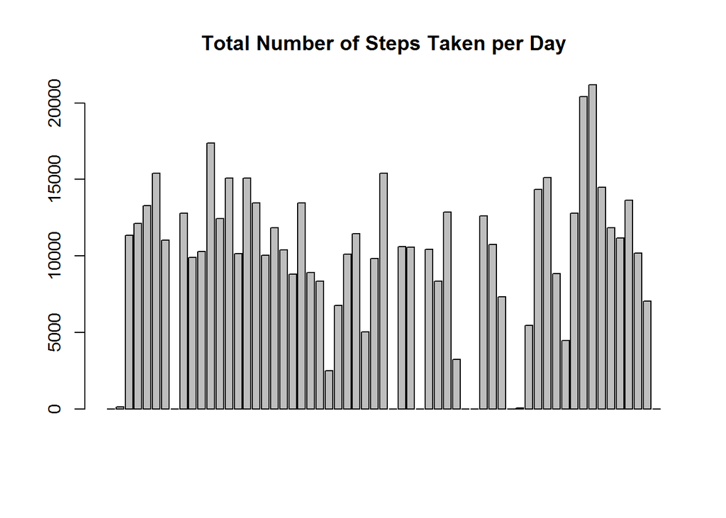

```r
summarized_data <- as.data.frame(summarize(group_by(rawdata, date), steps = sum(steps, na.rm = TRUE)))
barplot(summarized_data$steps, main = "Total Number of Steps Taken per Day")
```

**Task 3: Mean and median number of steps taken each day**

```r
mean_data <- as.data.frame(summarize(group_by(rawdata, date), mean_of_steps = mean(steps, na.rm = TRUE)))
head(mean_data, n = 5)
```

```
##         date mean_of_steps
## 1 2012-10-01           NaN
## 2 2012-10-02       0.43750
## 3 2012-10-03      39.41667
## 4 2012-10-04      42.06944
## 5 2012-10-05      46.15972
```

```r
median_data <- as.data.frame(summarize(group_by(rawdata, date), median_of_steps = median(steps)))
head(median_data, n = 5)
```

```
##         date median_of_steps
## 1 2012-10-01              NA
## 2 2012-10-02               0
## 3 2012-10-03               0
## 4 2012-10-04               0
## 5 2012-10-05               0
```

**Task 4: Time series plot of the average number of steps taken**

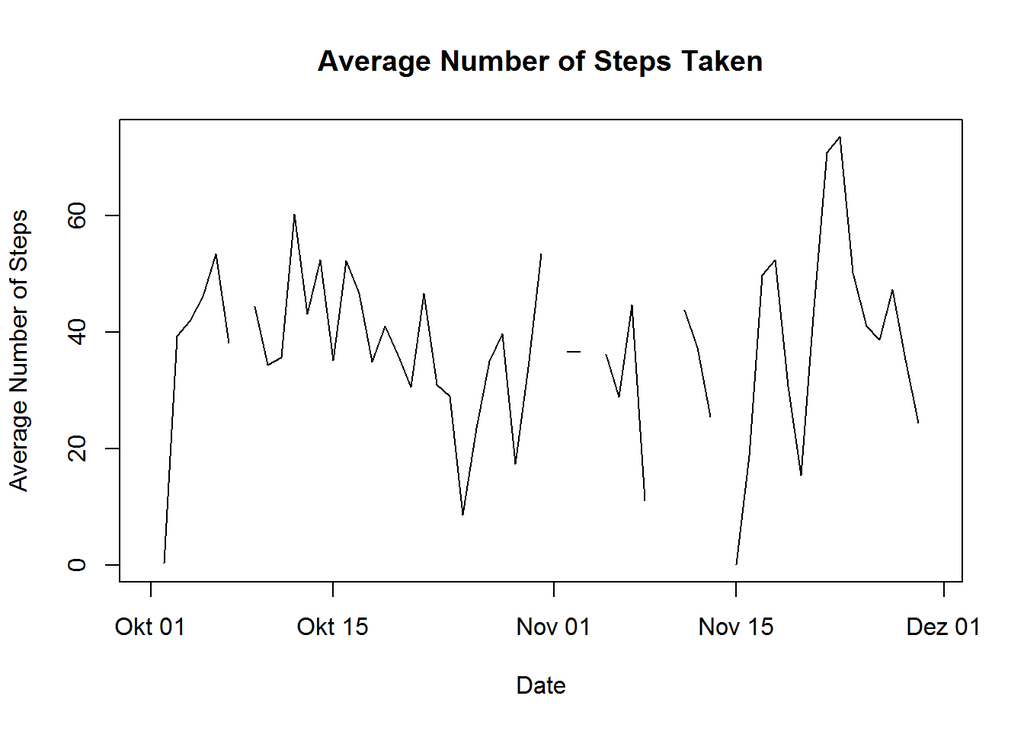

```r
plot(mean_data$date, mean_data$mean_of_steps, type = "l",
main = "Average Number of Steps Taken", xlab = "Date", ylab = "Average Number of Steps")
```

**Task 5: The 5-minute interval that, on average, contains the maximum number of steps**

```r
interval_data <- as.data.frame(summarize(group_by(rawdata, interval), steps = mean(steps, na.rm = TRUE)))
subset(interval_data, interval_data$steps == max(interval_data$steps))
```

```
##     interval    steps
## 104      835 206.1698
```

**Task 6: Code to describe and show a strategy for imputing missing data**  
Exploring the missing values

```r
na_data <- subset(rawdata, is.na(rawdata$steps))
unique(na_data$date)
```

```
## [1] "2012-10-01" "2012-10-08" "2012-11-01" "2012-11-04" "2012-11-09"
## [6] "2012-11-10" "2012-11-14" "2012-11-30"
```

The missing data is concentrated on eight days.  
To prevent a distortion of the data the average of the corresponding interval is assigned to all missing values.

```r
na_replace <- merge(interval_data, na_data[,2:3], by.x = "interval", by.y = "interval")
impute_data <- rbind(subset(rawdata, !is.na(rawdata$steps)), na_replace)
impute_data <- impute_data[order(impute_data$date, impute_data$interval),]
head(impute_data, n = 5)
```

```
##            steps       date interval
## 152651 1.7169811 2012-10-01        0
## 152741 0.3396226 2012-10-01        5
## 152811 0.1320755 2012-10-01       10
## 152931 0.1509434 2012-10-01       15
## 152971 0.0754717 2012-10-01       20
```

**Task 7: Histogram of the total number of steps taken each day after missing values are imputed**

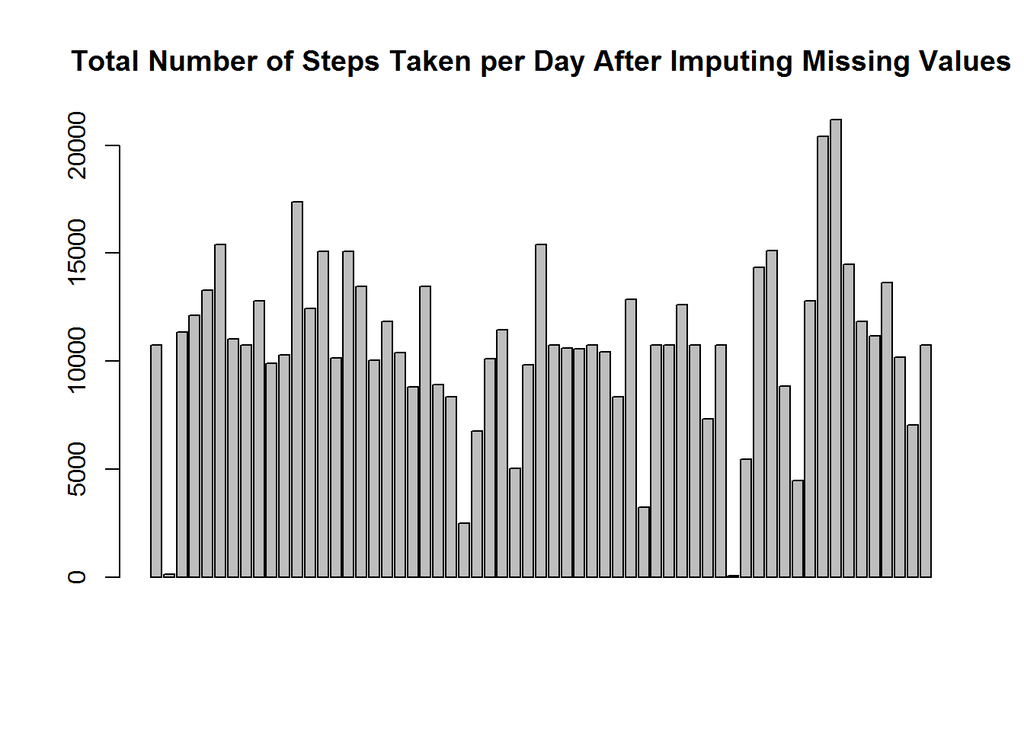

```r
summarized_impute_data <- as.data.frame(summarize(group_by(impute_data, date), steps = sum(steps, na.rm = TRUE)))
barplot(summarized_impute_data$steps, main = "Total Number of Steps Taken per Day After Imputing Missing Values")
```

**Task 8: Panel plot comparing the average number of steps taken per 5-minute interval across weekdays and weekends**

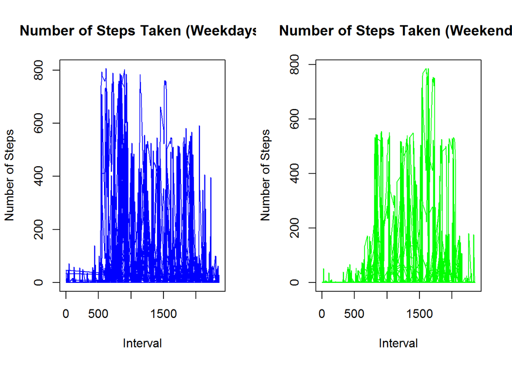

```r
impute_data$weekday <- weekdays(impute_data$date)
for(i in 1:nrow(impute_data)) {
  if(impute_data$weekday[i] %in% c("Montag", "Dienstag", "Mittwoch", "Donnerstag", "Freitag"))
    impute_data$weekday2[i] <- "Weekday"
  else impute_data$weekday2[i] <- "Weekend"
}
par(mfrow = c(1,2))
weekday_data <- subset(impute_data, weekday2 == "Weekday")
plot(weekday_data$interval, weekday_data$steps, type = 'l', col = 'blue',
     main = "Number of Steps Taken (Weekdays)", xlab = "Interval", ylab = "Number of Steps")
weekend_data <- subset(impute_data, weekday2 == "Weekend")
plot(weekend_data$interval, weekend_data$steps, type = 'l', col = 'green',
     main = "Number of Steps Taken (Weekend)", xlab = "Interval", ylab = "Number of Steps")
```